# hwk_3

Holden Jones

2025-02-03

```r
library(tidyverse)
library(effects)
library(DHARMa)
fish_data <- read_csv('data/fish_data.csv')
```

[output not shown]

# 1.

1. Let’s look at some basic summary statistics. In total there are 209 fish species encountered and counted in these surveys. Identify the top twelve species in terms of these three statistics: (1) mean abundance, (2) maximum abundance,
2. standard deviation of abundance. In other words, which species are most abundant on average, which reach the highest abundances, and which have the most variable abundances?

```r
# top 12 highest mean abundance
fish_data %>%
  group_by(taxonname) %>%
  summarize(mean_abun = mean(count, na.rm = TRUE)) %>%
  slice_max(order_by = mean_abun, n = 12)
```

```
## # A tibble: 12 × 2
##    taxonname                mean_abun
##    <chr>                        <dbl>
##  1 Chromis vanderbilti          30.4
##  2 Chromis agilis               19.0
##  3 Acanthurus nigrofuscus        6.22
##  4 Ctenochaetus strigosus        6.11
##  5 Zebrasoma flavescens          5.03
##  6 Lutjanus kasmira              4.87
##  7 Paracirrhites arcatus         2.95
##  8 Pristiapogon kallopterus      2.6
##  9 Chromis hanui                 2.56
## 10 Acanthurus leucopareius       2.47
## 11 Thalassoma duperrey           2.32
## 12 Decapterus macarellus         1.84
```

```r
# top 12 highest max abundance
fish_data %>%
  group_by(taxonname) %>%
  summarize(max_abun = max(count, na.rm = TRUE)) %>%
  slice_max(order_by = max_abun, n = 12)
```

```
## # A tibble: 12 × 2
##    taxonname                   max_abun
##    <chr>                          <dbl>
##  1 Lutjanus kasmira                 600
##  2 Chromis agilis                   500
##  3 Chromis vanderbilti              500
##  4 Chromis hanui                    200
##  5 Chromis ovalis                   150
##  6 Decapterus macarellus            150
##  7 Spratelloides delicatulus        150
##  8 Chromis verater                  100
##  9 Pseudocheilinus evanidus         100
## 10 Mulloidichthys vanicolensis       90
## 11 Apogon kallopterus                86
## 12 Chromis leucura                   80
```

```r
# top 12 highest sd abundance
fish_data %>%
  group_by(taxonname) %>%
  summarize(sd_abun = sd(count, na.rm = TRUE)) %>%
  slice_max(order_by = sd_abun, n = 12)
```

```
## # A tibble: 12 × 2
##    taxonname                 sd_abun
##    <chr>                       <dbl>
##  1 Chromis vanderbilti         52.7
##  2 Chromis agilis              41.7
##  3 Lutjanus kasmira            31.5
##  4 Chromis hanui               10.6
##  5 Chromis ovalis               9.45
##  6 Decapterus macarellus        9.36
##  7 Spratelloides delicatulus    7.96
##  8 Ctenochaetus strigosus       6.47
##  9 Zebrasoma flavescens         6.00
## 10 Acanthurus nigrofuscus       5.99
## 11 Pseudocheilinus evanidus     5.92
## 12 Myripristis kuntee           4.92
```

# 2.

2. Now let’s visualize how the abundances of the most common species vary with depth, to get a sense for whether species have different depth niches. Using the top twelve species based on mean abundance, plot a scatterplot of count vs. depth (the column is named ‘depth’). Add a smoother to help visualize mean count vs. depth, put all twelve species on a single plot (with twelve panels), and make sure each panel is titled using the species name. Furthermore, do not arrange the panels in alphabetical order — instead, arrange them in order of mean abundance, so that the most abundant species is in the top left panel, and remaining panels are in order of mean abundance. The patterns in abundance will be easier to see if you transform the counts or the y-axis, for example with a square root, because the counts are very skewed.

start by making a vector of the top 12 sp in abundance - subset df to just these

```r
top_taxa <- fish_data %>%
  group_by(taxonname) %>%
  summarize(mean_abun = mean(count, na.rm = TRUE)) %>%
  slice_max(order_by = mean_abun, n = 12) %>%
  pull(taxonname)
top_taxa # ranked top 12 species - chromis vanderbelti first
```

```
##  [1] "Chromis vanderbilti"      "Chromis agilis"
##  [3] "Acanthurus nigrofuscus"   "Ctenochaetus strigosus"
##  [5] "Zebrasoma flavescens"     "Lutjanus kasmira"
##  [7] "Paracirrhites arcatus"    "Pristiapogon kallopterus"
##  [9] "Chromis hanui"            "Acanthurus leucopareius"
## [11] "Thalassoma duperrey"      "Decapterus macarellus"
```

```r
# filter df taxonname ranked by top_taxa
filter_fish <- fish_data %>%
  filter(taxonname %in% top_taxa) %>%
  mutate(taxonname = factor(taxonname, levels = top_taxa))
```

for loop plot

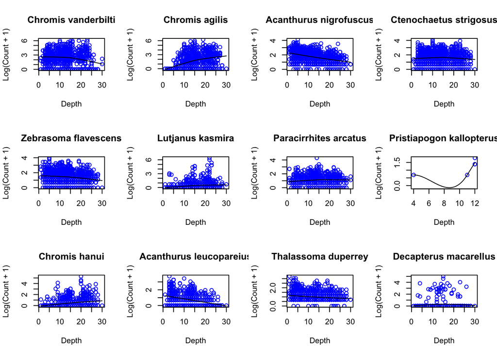

```r
par(mfrow = c(3, 4))

for (i in top_taxa) { # loop over the top 12 taxa
  plot_data <- filter_fish %>% filter(taxonname == i) # filter for i taxa

    scatter.smooth(plot_data$depth, log1p(plot_data$count), # log1p solved 0 problem
               span = 1,
               main = i,
               xlab = "Depth",
               ylab = "Log(Count + 1)",
               col = "blue")
}
```

ggplot

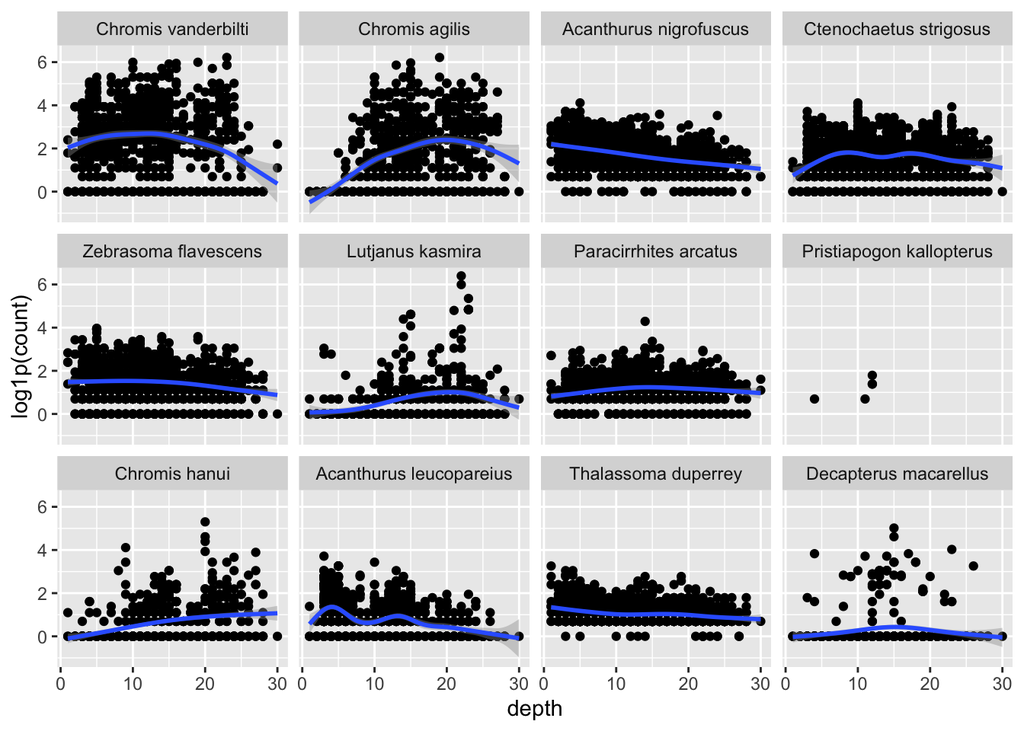

```r
count_depth_plot <- filter_fish %>%
                    ggplot(aes(x = depth, y = log1p(count))) +
                      geom_point() +
                      geom_smooth() +
                      facet_wrap(~ taxonname)
count_depth_plot
```

What are your conclusions from this visual inspection of the data? Make sure that the patterns in the plots are visible. If they are not, you may need to adjust the figure dimensions in Markdown.

- Abundance peaks at intermediate depth for the two most abundant species. Each species responds differently to depth. For example the 3rd and 5th most abundant species decrease in abundance as depth increases. C. hanui actually increases in abundance at higher depths.
- This suggests a quadratic model might be appropriate, esp. for some species like C. vanderbilti and C. agillis
- P. kallopteris had extremely low frequency of being detected, so I’d probably remove this from analysis. We don’t know enough about it to say how it responds to depth yet.

# 3.

3. Finally, let’s focus on just the top 5 most abundant species. Make a new plot that shows abundance vs. depth for the top 5 species, including smoothers, but this time put all of the species on the same scatterplot and distinguish them with different colors. This time you don’t need to use two different approaches to make the plot — one approach will suffice.

subset by only the top 5 taxa

```r
top_five <- fish_data %>%
  group_by(taxonname) %>%
  summarize(mean_abun = mean(count, na.rm = TRUE)) %>%
  slice_max(order_by = mean_abun, n = 5) %>%
  pull(taxonname)
top_five # ranked top 5 species - chromis vanderbelti first
```

```
## [1] "Chromis vanderbilti"    "Chromis agilis"         "Acanthurus nigrofuscus"
## [4] "Ctenochaetus strigosus" "Zebrasoma flavescens"
```

```r
# filter df taxonname ranked by top_five
filter_fish <- fish_data %>%
  filter(taxonname %in% top_five) %>%
  mutate(taxonname = factor(taxonname, levels = top_five))
```

plot top 5

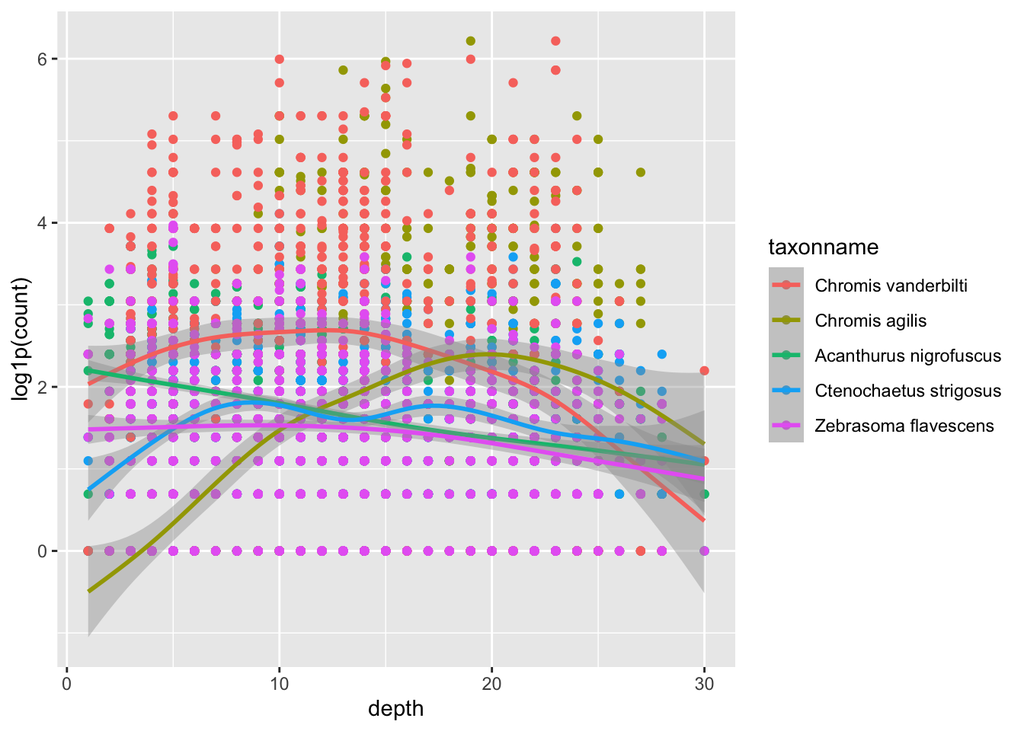

```r
count_depth_plot_5 <- filter_fish %>%
                    ggplot(aes(x = depth, y = log1p(count),
                               color = taxonname)) +
                      geom_point() +
                      geom_smooth()
count_depth_plot_5
```

What is your interpretation of this plot?

- The top 5 most abundant species all respond differently to depth!
- C. vanderbilti and C. agillis peak at intermediate depths
- C. strigosus appears to have bimodal peaks
- A. nigrofuscus and Z. flavescens both appear to decrease in abundace with depth

Fit a linear model that tests whether these 5 species have different depth niches.

```r
depth_model <- lm(log1p(count) ~ depth + taxonname +
                   depth*taxonname,
            data = filter_fish)
summary(depth_model)
```

```
##
## Call:
## lm(formula = log1p(count) ~ depth + taxonname + depth * taxonname,
##     data = filter_fish)
##
## Residuals:
##     Min      1Q  Median      3Q     Max
## -3.2082 -0.6669  0.0169  0.6827  4.3142
##
## Coefficients:
##                                        Estimate Std. Error t value Pr(>|t|)
## (Intercept)                            2.805900   0.074321  37.754  < 2e-16 ***
## depth                                 -0.031763   0.005293  -6.001 2.07e-09 ***
## taxonnameChromis agilis               -2.529996   0.114709 -22.056  < 2e-16 ***
## taxonnameAcanthurus nigrofuscus       -0.583171   0.095279  -6.121 9.90e-10 ***
## taxonnameCtenochaetus strigosus       -1.222164   0.098739 -12.378  < 2e-16 ***
## taxonnameZebrasoma flavescens         -1.131637   0.099192 -11.409  < 2e-16 ***
## depth:taxonnameChromis agilis          0.129506   0.007659  16.910  < 2e-16 ***
## depth:taxonnameAcanthurus nigrofuscus -0.010273   0.006778  -1.516   0.1297
## depth:taxonnameCtenochaetus strigosus  0.032328   0.006848   4.721 2.40e-06 ***
## depth:taxonnameZebrasoma flavescens    0.013217   0.006893   1.917   0.0552 .
## ---
## Signif. codes:  0 '***' 0.001 '**' 0.01 '*' 0.05 '.' 0.1 ' ' 1
##
## Residual standard error: 1.076 on 6094 degrees of freedom
## Multiple R-squared:  0.1387, Adjusted R-squared:  0.1374
## F-statistic: 109.1 on 9 and 6094 DF,  p-value: < 2.2e-16
```

residual diagnostics and effects plots

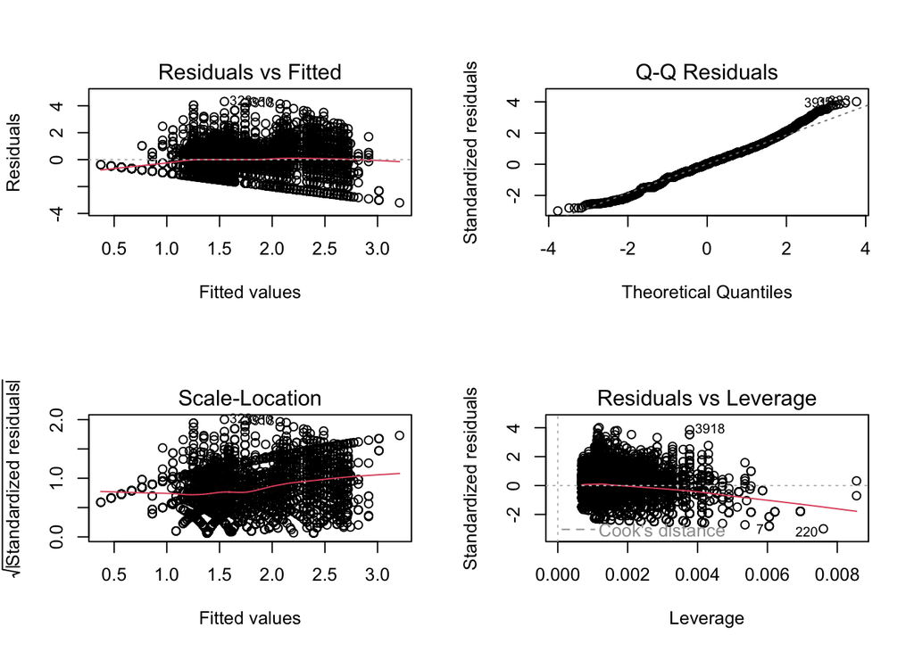

```r
par(mfrow = c(2, 2))
plot(depth_model)
```

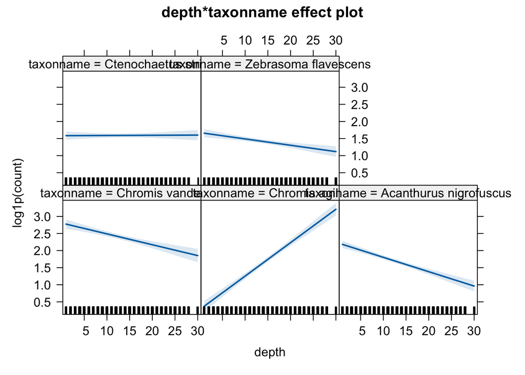

```r
plot(allEffects(depth_model))
```

confirm using dHARMA

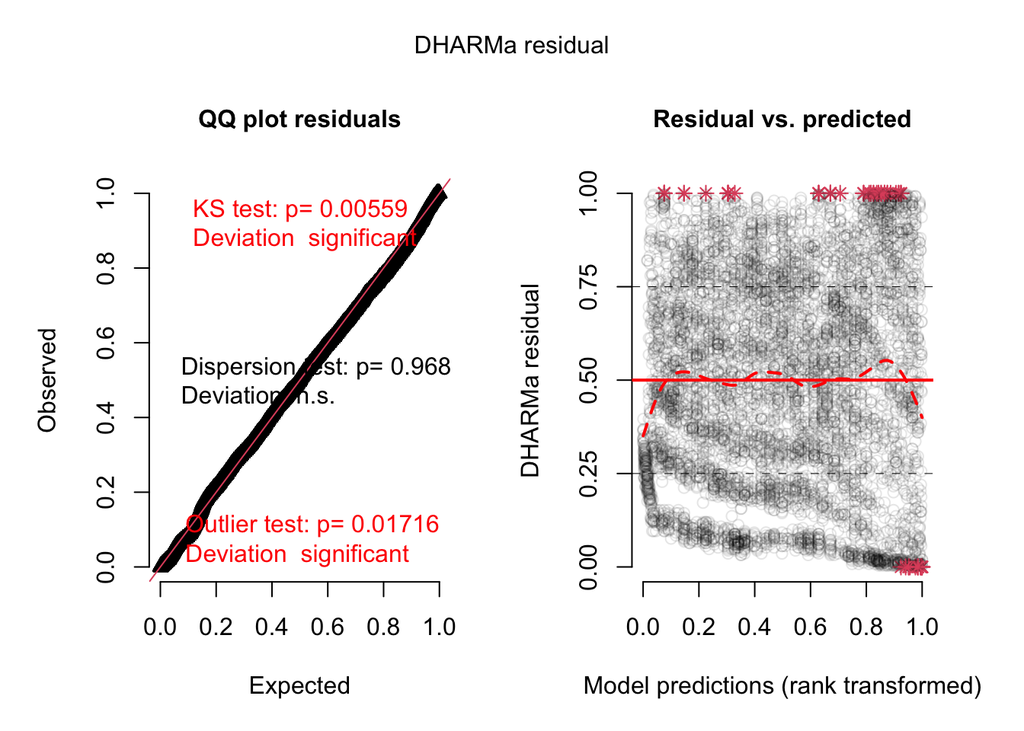

```r
simulationOutput <- simulateResiduals(fittedModel = depth_model)
plot(simulationOutput)
```

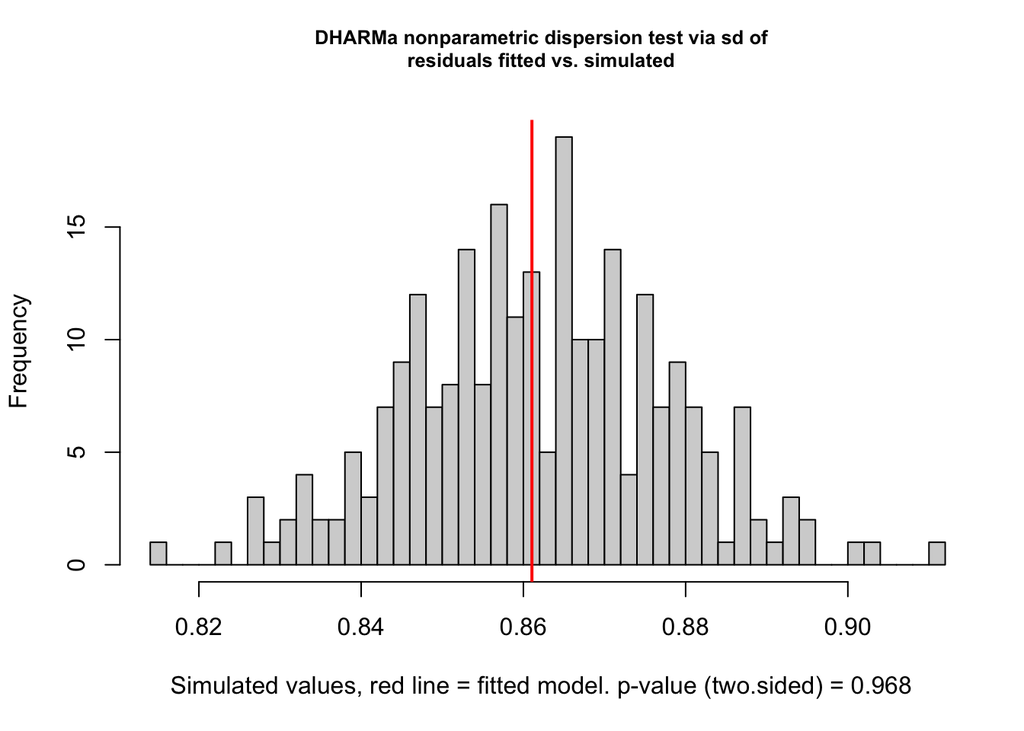

```
##
##  DHARMa nonparametric dispersion test via sd of residuals fitted vs.
##  simulated
##
## data:  simulationOutput
## dispersion = 0.99919, p-value = 0.968
## alternative hypothesis: two.sided
```

```r
testDispersion(simulationOutput)
```

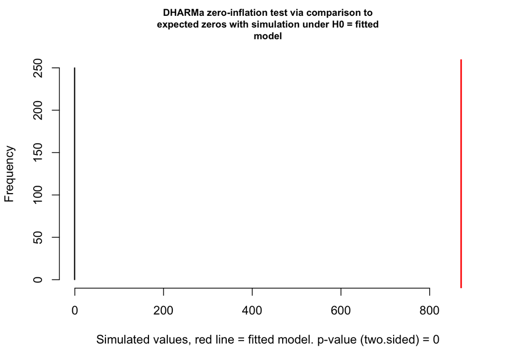

```
##
##  DHARMa zero-inflation test via comparison to expected zeros with
##  simulation under H0 = fitted model
##
## data:  simulationOutput
## ratioObsSim = Inf, p-value < 2.2e-16
## alternative hypothesis: two.sided
```

```r
testZeroInflation(simulationOutput)
```

Based on residual diagnostic plots of this model, and a plot of the fitted effects, do you think a linear model is a good approach for testing this question? If not, why not?

- No, I do not think a linear model is a good approach for asking if there is a reaction between species and depth for abundance
- The residual diagnostic plots look horrible! Residuals clearly are not evenly distributed across all depth values. So a linear model is not accurately capturing the effect of different depths on abundance for different species
- Seems like we need to use a quadratic model…